# Practical Examples and Use Cases

## Example 13: Bound Spread Analysis

Analyze how the spread of arithmetic Asian bounds changes with $n$:

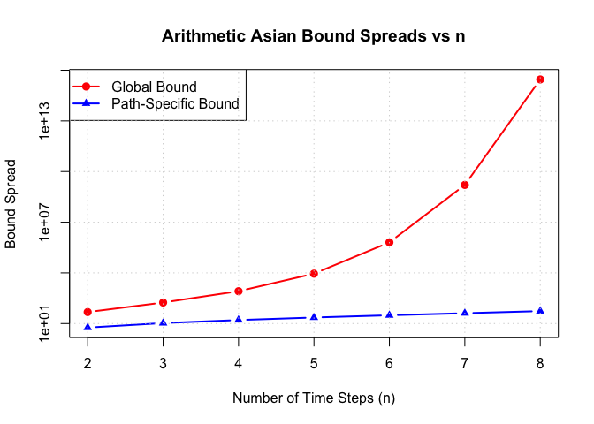

```r
n_values <- 2:8
global_spreads <- numeric(length(n_values))
ps_spreads <- numeric(length(n_values))

for (i in seq_along(n_values)) {
  n <- n_values[i]
  bounds <- arithmetic_asian_bounds(100, 100, 1.05, 1.2, 0.8, 0.1, 1, 1, n,
                                     compute_path_specific = TRUE)
  global_spreads[i] <- bounds$upper_bound_global - bounds$lower_bound
  ps_spreads[i] <- bounds$upper_bound_path_specific - bounds$lower_bound
}

plot(n_values, global_spreads, type = "b", col = "red", pch = 19, lwd = 2,
     xlab = "Number of Time Steps (n)",
     ylab = "Bound Spread",
     main = "Arithmetic Asian Bound Spreads vs n",
     log = "y", ylim = range(c(global_spreads, ps_spreads)))
lines(n_values, ps_spreads, type = "b", col = "blue", pch = 17, lwd = 2)
legend("topleft",
       legend = c("Global Bound", "Path-Specific Bound"),
       col = c("red", "blue"), pch = c(19, 17), lty = 1, lwd = 2)
grid()
```

**Observation**: Both bound spreads increase with $n$, but the path-specific bound remains much tighter than the global bound.

## Example 14: Multiple Price Impact Scenarios

Compare geometric Asian option prices under different price impact regimes:

```r
# Define scenarios
scenarios <- list(
  "No Impact" = list(lambda = 0, v_u = 0, v_d = 0),
  "Low Impact" = list(lambda = 0.05, v_u = 1, v_d = 1),
  "Medium Impact" = list(lambda = 0.1, v_u = 1, v_d = 1),
  "High Impact" = list(lambda = 0.2, v_u = 1, v_d = 1),
  "Asymmetric" = list(lambda = 0.1, v_u = 1.5, v_d = 0.5)
)

n_vals <- 3:10
results <- matrix(NA, nrow = length(n_vals), ncol = length(scenarios))
colnames(results) <- names(scenarios)
rownames(results) <- paste0("n=", n_vals)

for (j in seq_along(scenarios)) {
  sc <- scenarios[[j]]
  for (i in seq_along(n_vals)) {
    results[i, j] <- price_geometric_asian(
      100, 100, 1.05, 1.2, 0.8, sc$lambda, sc$v_u, sc$v_d, n_vals[i]
    )
  }
}

print(round(results, 2))
```

```
#>      No Impact Low Impact Medium Impact High Impact Asymmetric
#> n=3       9.94      11.18         12.35       14.44      12.46
#> n=4      11.73      13.10         14.38       16.62      14.41
#> n=5      13.26      14.58         15.81       18.03      15.89
#> n=6      14.59      15.90         17.11       19.13      17.13
#> n=7      15.75      17.00         18.15       20.10      18.17
#> n=8      16.79      17.99         19.07       20.79      19.04
#> n=9      17.71      18.82         19.80       21.35      19.77
#> n=10     18.52      19.53         20.44       21.74      20.37
```

## Summary

This vignette demonstrated:

1. **Basic pricing**: Geometric Asian options with and without price impact
2. **Parameter sensitivity**: Effects of $\lambda$, strike, volumes
3. **Option types**: Calls, puts, European, Asian
4. **Arithmetic bounds**: Global and path-specific bounds
5. **Comparative analysis**: Impact vs no impact, European vs Asian
6. **Advanced topics**: Asymmetric hedging, moneyness, convergence

**Key Insights**:

- **Exact computation**: All prices use complete path enumeration (no sampling)
- **Efficiency**: Optimal for n ≤ 20 (fast and exact)
- **Price impact**: Systematically increases option values
- **Path-specific bounds**: Provide much tighter estimates than global bounds
- **Flexibility**: Supports calls, puts, symmetric and asymmetric hedging

For theoretical details, see `vignette("theory")`.

## References

Tiwari, P., & Majumdar, S. (2024). Asian option valuation under price impact. *arXiv preprint*. https://doi.org/10.48550/arXiv.2512.07154